# Random forests for classification and regression. Practical examples in R

## Boosted trees. Adabag method

### Example 4: Boosted trees for classification with the `meteo` dataset

We illustrate gradient boosting using the `adabag` package (Alfaro y García 2013). We use the `meteo` dataset again, as previously pre-processed in Example 2. This is a brief example on how to apply adabag, that will be extended during the gradient boosting lab session.

```r
if (!require("adabag")) install.packages("adabag")
library("adabag")
```

```r
ab <- boosting(y.bin ~., df.occ[indtrain, ], mfinal = 20)
```

The function `errorevol`caclulates how the classification/prediction error evolves as the ensemble size grows.

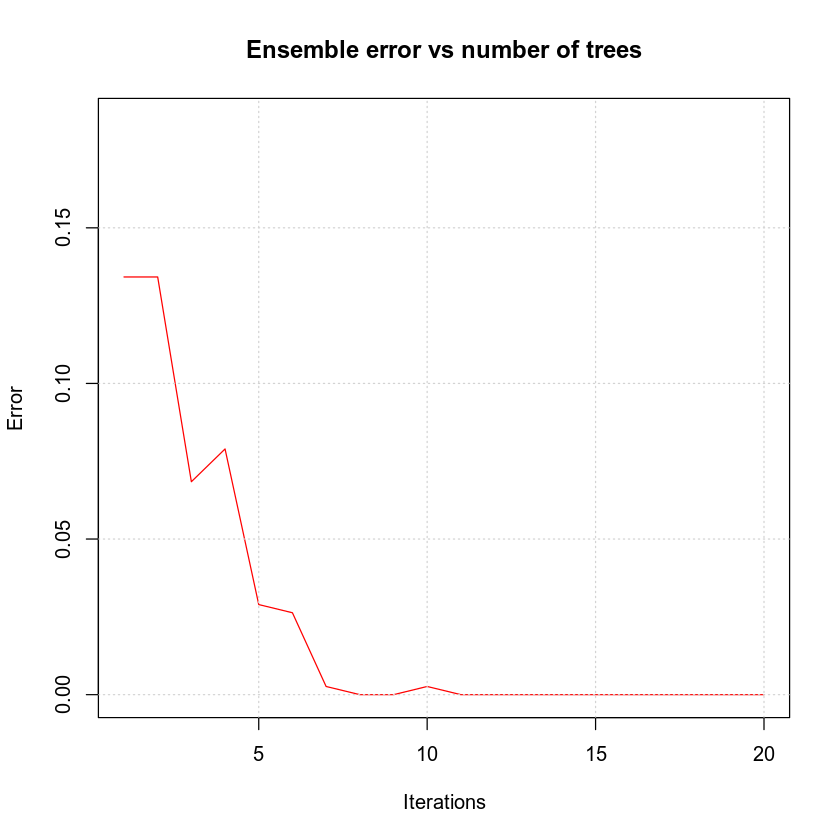

```r
plot(errorevol(ab, df.occ[indtrain, ]))
grid()
```

It is possible to extract individual trees generated during the boosting procedure to investigate the process:

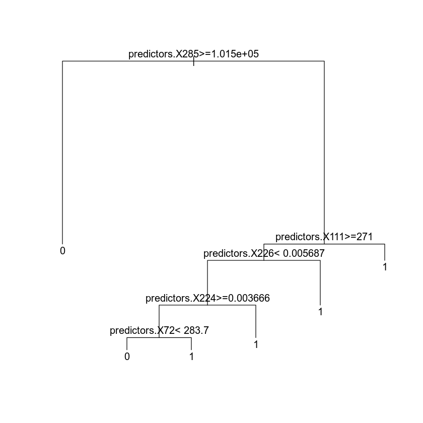

```r
plot(ab$trees[[1]])
text(ab$trees[[1]])
```

We next depict the sequential tree generation by displaying some intermediate trees from the first to the 20th:

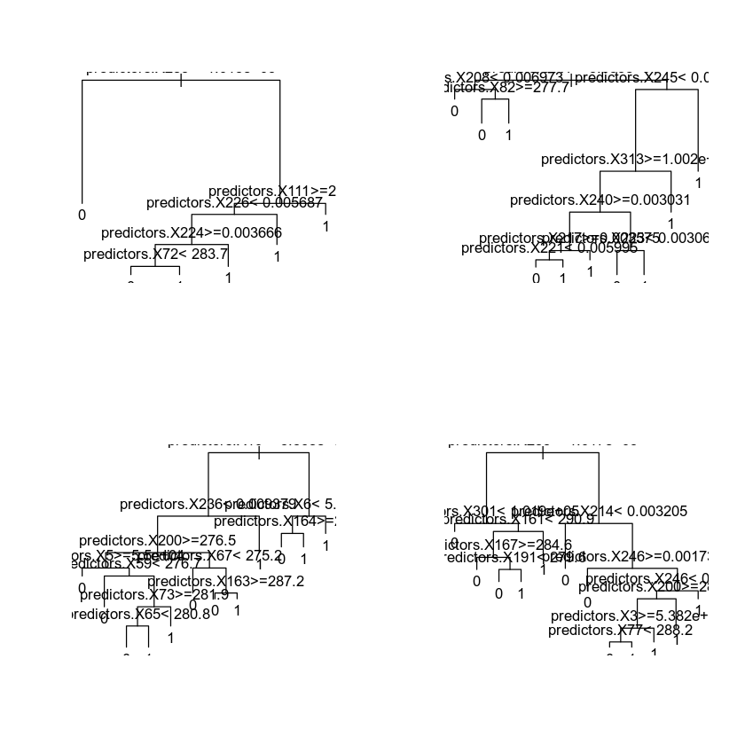

```r
par(mfrow=c(2,2))
for (i in c(1,5,10,20)) {
    plot(ab$trees[[i]])
    text(ab$trees[[i]])
}
```

Finally, we obtain the prediction error (as 1-accuracy):

```r
## prediction for test
pred.ab <- predict(ab, df.occ[indtest, ])
# test error
1 - sum(diag(table(pred.ab$class, df.occ$y.bin[indtest]))) / length(indtest)
```

0.150793650793651

## References

- Alfaro, E., Gamez, M. Garcia, N.(2013). adabag: An R Package for Classification with Boosting and Bagging. Journal of Statistical Software, 54(2), 1-35. URL http://www.jstatsoft.org/v54/i02/.
- Liaw, A. and Wiener, M. (2002). Classification and Regression by randomForest. R News 2(3), 18--22.